# Project Python Foundations: FoodHub Data Analysis

# Observations

- Delivery time is fairly consistent.
- Customers wait an average of 24 minutes for delivery.

# **Restaurant Name**

```python
df['restaurant_name'].describe()
```

|  | restaurant_name |
| --- | --- |
| count | 1898 |
| unique | 178 |
| top | Shake Shack |
| freq | 219 |

**dtype:** object

```python
df['restaurant_name'].value_counts()
```

| restaurant_name | count |
| --- | --- |
| Shake Shack | 219 |
| The Meatball Shop | 132 |
| Blue Ribbon Sushi | 119 |
| Blue Ribbon Fried Chicken | 96 |
| Parm | 68 |
| ... | ... |
| Rye House | 1 |
| Hiroko's Place | 1 |
| Frank Restaurant | 1 |
| Sarabeth's West | 1 |
| 'wichcraft | 1 |

178 rows × 1 columns

**dtype:** int64

```python
df['restaurant_name'].nunique()
```

```
178
```

[figure not shown]

```python
sns.boxplot(data=df, x='restaurant_name')
plt.show()
```

# Observations

- Shake Shack has the most number of orders.
- There is a large customer demand on specific restaurants.

# **Cuisine**

```python
df['cuisine_type'].nunique()
```

```
14
```

```python
df['cuisine_type'].describe()
```

|  | cuisine_type |
| --- | --- |
| count | 1898 |
| unique | 14 |
| top | American |
| freq | 584 |

**dtype:** object

```python
df['cuisine_type'].value_counts()
```

| cuisine_type | count |
| --- | --- |
| American | 584 |
| Japanese | 470 |
| Italian | 298 |
| Chinese | 215 |
| Mexican | 77 |
| Indian | 73 |
| Middle Eastern | 49 |
| Mediterranean | 46 |
| Thai | 19 |
| French | 18 |
| Southern | 17 |
| Korean | 13 |
| Spanish | 12 |
| Vietnamese | 7 |

**dtype:** int64

Observations:

- The cuisine types that is most popular are American food, Japanese food, and Italian Food.
- Out of the 1898 orders, 584 of those orders are American food.

# **Cost of Order**

```python
mean_cost_of_order = df['cost_of_the_order'].mean()
print(f"The mean cost of the order is: {mean_cost_of_order:.2f}")
```

```
The mean cost of the order is: 16.50
```

```python
min_cost_of_order = df['cost_of_the_order'].min()
print(f"The minimum cost of the order is: {min_cost_of_order:.2f}")
```

```
The minimum cost of the order is: 4.47
```

```python
max_cost_of_order = df['cost_of_the_order'].max()
print(f"The maximum cost of the order is: ${max_cost_of_order:.2f}")
```

```
The maximum cost of the order is: $35.41
```

```python
df['cost_of_the_order'].describe()
```

|  | cost_of_the_order |
| --- | --- |
| count | 1898.000000 |
| mean | 16.498851 |
| std | 7.483812 |
| min | 4.470000 |
| 25% | 12.080000 |
| 50% | 14.140000 |
| 75% | 22.297500 |
| max | 35.410000 |

**dtype:** float64

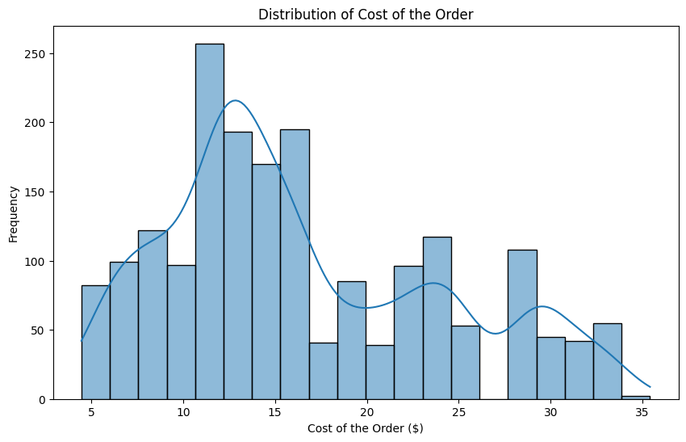

```python
plt.figure(figsize=(10, 6))
sns.histplot(df['cost_of_the_order'], bins=20, kde=True)
plt.title('Distribution of Cost of the Order')
plt.xlabel('Cost of the Order ($)')
plt.ylabel('Frequency')
plt.show()
```

Observations:

# **Days of the week**

```python
df.head()
```

|  | Unnamed: 0 | customer_id | restaurant_name | cuisine_type | cost_of_the_order | day_of_the_week | rating | food_preparation_time | delivery_time | total_time |
| --- | --- | --- | --- | --- | --- | --- | --- | --- | --- | --- |
| 0 | order_id | 337525.0 | Hangawi | Korean | 30.75 | Weekend | Not given | 25.0 | 20.0 | 45.0 |
| 1 | 1477147 | 358141.0 | Blue Ribbon Sushi Izakaya | Japanese | 12.08 | Weekend | Not given | 25.0 | 23.0 | 48.0 |
| 2 | 1477685 | 66393.0 | Cafe Habana | Mexican | 12.23 | Weekday | 5 | 23.0 | 28.0 | 51.0 |
| 3 | 1477070 | 106968.0 | Blue Ribbon Fried Chicken | American | 29.20 | Weekend | 3 | 25.0 | 15.0 | 40.0 |
| 4 | 1477334 | 76942.0 | Dirty Bird to Go | American | 11.59 | Weekday | 4 | 25.0 | 24.0 | 49.0 |

```python
df['day_of_the_week'].describe()
```

|  | day_of_the_week |
| --- | --- |
| count | 1898 |
| unique | 2 |
| top | Weekend |
| freq | 1351 |

**dtype:** object

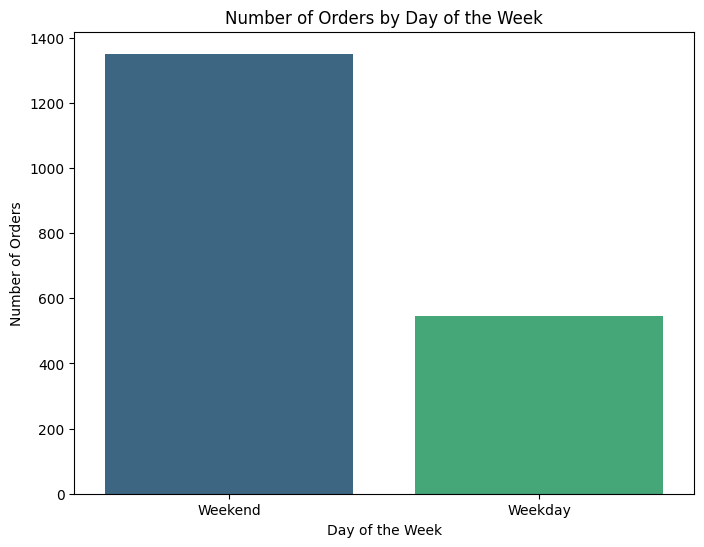

```python
plt.figure(figsize=(8, 6))
sns.countplot(data=df, x='day_of_the_week', palette='viridis', hue='day_of_the_week', legend=False)
plt.title('Number of Orders by Day of the Week')
plt.xlabel('Day of the Week')
plt.ylabel('Number of Orders')
plt.show()
```

```python
df['day_of_the_week'].value_counts(normalize = True)
```

| day_of_the_week | proportion |
| --- | --- |
| Weekend | 0.711802 |
| Weekday | 0.288198 |

**dtype:** float64

Observations:

- The plot shows that the number of orders on the weekend is higher than the ones during the weekday.

# **Rating**

```python
df['rating'].nunique()
```

```
4
```

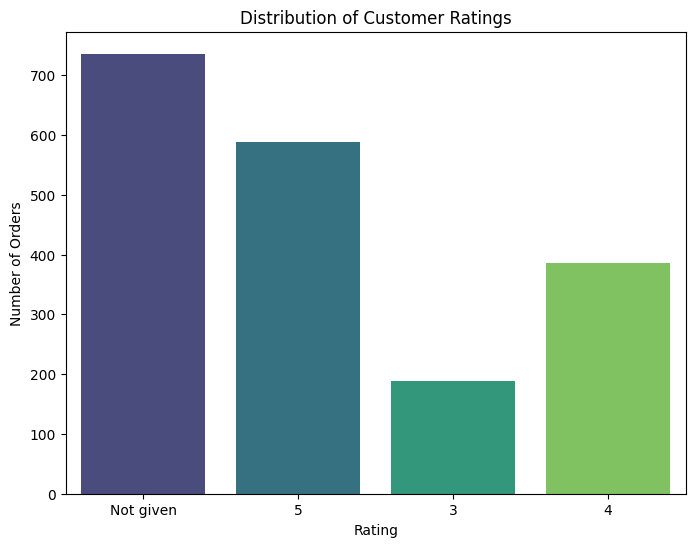

```python
plt.figure(figsize=(8, 6))
sns.countplot(data=df, x='rating', palette='viridis', hue='rating', legend=False)
plt.title('Distribution of Customer Ratings')
plt.xlabel('Rating')
plt.ylabel('Number of Orders')
plt.show()
```

```python
df['rating'] != 'Not given'
```

|  | rating |
| --- | --- |
| 0 | False |
| 1 | False |
| 2 | True |
| 3 | True |
| 4 | True |
| ... | ... |
| 1894 | True |
| 1895 | False |
| 1896 | True |
| 1897 | False |
| 1898 | True |

1899 rows × 1 columns

**dtype:** bool

# **Food Preparation Time**

```python
df['food_preparation_time'].nunique()
```

```
16
```

```python
df['food_preparation_time'].describe()
```

|  | food_preparation_time |
| --- | --- |
| count | 1898.000000 |
| mean | 27.371970 |
| std | 4.632481 |
| min | 20.000000 |
| 25% | 23.000000 |
| 50% | 27.000000 |
| 75% | 31.000000 |
| max | 35.000000 |

**dtype:** float64

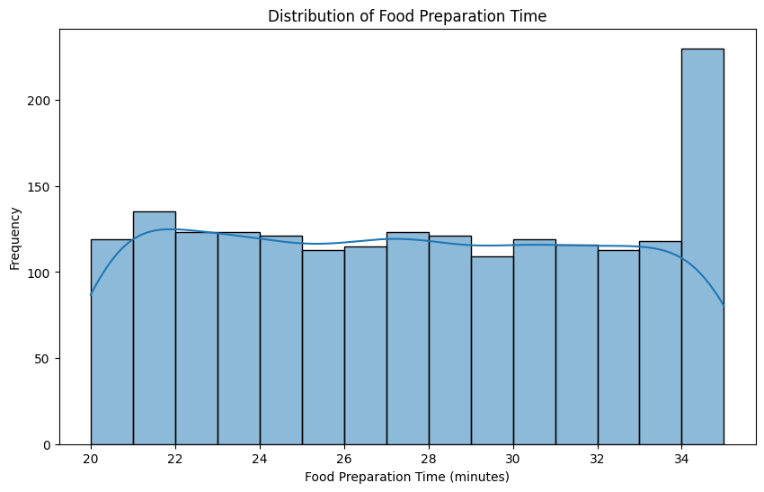

```python
plt.figure(figsize=(10, 6))
sns.histplot(df['food_preparation_time'], bins=15, kde=True)
plt.title('Distribution of Food Preparation Time')
plt.xlabel('Food Preparation Time (minutes)')
plt.ylabel('Frequency')
plt.show()
```

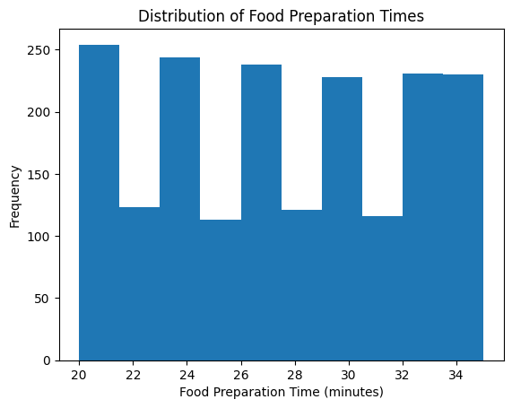

```python
import matplotlib.pyplot as plt

plt.hist(df['food_preparation_time'], bins=10)

plt.xlabel('Food Preparation Time (minutes)')
plt.ylabel('Frequency')
plt.title('Distribution of Food Preparation Times')

plt.show()
```

```python
average_prep_time = df_cleaned.groupby(
    ['restaurant_name', 'cuisine_type']
)['food_preparation_time'].mean().reset_index()

average_prep_time['food_preparation_time'] = average_prep_time[
    'food_preparation_time'
].round(2)

average_prep_time = average_prep_time.sort_values(
    'food_preparation_time',
    ascending=False
)

average_prep_time
```

|  | restaurant_name | cuisine_type | food_preparation_time |
| --- | --- | --- | --- |
| 39 | Cipriani Le Specialita | Italian | 35.0 |
| 83 | Kambi Ramen House | Japanese | 35.0 |
| 85 | Klong | Thai | 35.0 |
| 140 | Sushi Choshi | Japanese | 35.0 |
| 148 | Taro Sushi | Japanese | 35.0 |
| ... | ... | ... | ... |
| 96 | Market Table | American | 21.0 |
| 43 | DespaÌ±a | Spanish | 20.5 |
| 3 | 67 Burger | American | 20.0 |
| 58 | Frank Restaurant | Italian | 20.0 |
| 68 | Haru Gramercy Park | Japanese | 20.0 |

179 rows × 3 columns

```python
top_longest_prep_restaurants = average_prep_time.head(10)['restaurant_name']

# Get the cuisine type for these restaurants from the cleaned dataframe
longest_prep_cuisine = df_cleaned[df_cleaned['restaurant_name'].isin(top_longest_prep_restaurants)]['cuisine_type'].value_counts()
display(longest_prep_cuisine)
```

| cuisine_type | count |
| --- | --- |
| Chinese | 3 |
| Japanese | 3 |
| Thai | 2 |
| Italian | 2 |
| American | 1 |

**dtype:** int64

```python
average_prep_time = df.groupby(
    ['restaurant_name', 'cuisine_type']
)['food_preparation_time'].mean().reset_index()

average_prep_time['food_preparation_time'] = average_prep_time[
    'food_preparation_time'
].round(2)

average_prep_time = average_prep_time.sort_values(
    'food_preparation_time',
    ascending=False
)

average_prep_time['food_preparation_time'].nunique()
```

```
92
```

Observations